# Predicting Hit Songs - Hot 100 Billboard Chart

Frank K. Saforo  
Chris J. Ezelle

February 22, 2019

# Overview

- Introduction
- The Data and EDA
- Model Building and Evaluation
- Results and Interpretation
- Recommendation and Conclusion

# Introduction

# Collecting the Data

[figure not shown]

- **Latest data retrieval was on December 28, 2018**

# Data Snap

|  | acousticness | danceability | duration_ms | energy | instrumentalness | key | liveness | loudness | mode | speechiness | tempo | time_signature | valence | popularity |
| --- | --- | --- | --- | --- | --- | --- | --- | --- | --- | --- | --- | --- | --- | --- |
| 1 | 0.00582 | 0.743 | 238373 | 0.339 | 0 | 1 | 0.0812 | -7.678 | 1 | 0.409 | 203.927 | 4 | 0.118 | 0.44 |
| 3 | 0.025 | 0.603 | 138913 | 0.723 | 0 | 9 | 0.0824 | -5.89 | 0 | 0.0454 | 114.966 | 4 | 0.382 | 0.63 |
| 49 | 0.925 | 0.611 | 217466 | 0.238 | 3.91e-06 | 11 | 0.123 | -11.93 | 1 | 0.0356 | 122.047 | 4 | 0.248 | 0.4 |
| 51 | 0.122 | 0.552 | 241160 | 0.789 | 4.98e-06 | 9 | 0.0874 | -5.449 | 1 | 0.0242 | 93.938 | 4 | 0.349 | 0.53 |
| 57 | 0.774 | 0.523 | 258255 | 0.615 | 2.01e-05 | 0 | 0.365 | -8.136 | 1 | 0.0361 | 95.087 | 4 | 0.637 | 0.4 |
| 63 | 0.539 | 0.733 | 167920 | 0.489 | 0.00019 | 8 | 0.102 | -9.538 | 1 | 0.306 | 139.949 | 4 | 0.689 | 0.19 |
| 66 | 0.927 | 0.336 | 102570 | 0.294 | 0.968 | 8 | 0.0965 | -15.374 | 1 | 0.033 | 141.452 | 4 | 0.156 | 0.34 |
| 72 | 0.000426 | 0.441 | 151900 | 0.472 | 0.0019 | 6 | 0.115 | -12.172 | 0 | 0.0363 | 131.964 | 4 | 0.0655 | 0.24 |
| 73 | 8.96e-05 | 0.483 | 237556 | 0.743 | 0.00208 | 6 | 0.11 | -10.563 | 0 | 0.097 | 132.01 | 4 | 0.102 | 0.22 |
| 83 | 0.0879 | 0.527 | 35990 | 0.757 | 0 | 4 | 0.454 | -10.241 | 0 | 0.298 | 67.019 | 3 | 0.953 | 0.17 |

```r
str(newdata)
```

```
## 'data.frame':    116372 obs. of  25 variables:
##  $ artist_name     : Factor w/ 32105 levels "'Dwellers","'Lgado",..: 2005 7823 2619 18797 29586 15958 11603 23036 31324 25793 ...
##  $ track_id        : Factor w/ 116191 levels "0009UBVA8DCDwk1Hepib6P",..: 40722 72528 15225 33984 43501 112109 84094 17369 37845 28857 ...
##  $ track_name      : Factor w/ 96809 levels "'03","'84","'89 Chevy",..: 81715 80703 53924 36049 73731 96702 94461 79268 7262 54642 ...
##  $ acousticness    : num  0.28 0.153 0.0141 0.191 0.00513 0.071 0.297 0.551 0.0302 0.194 ...
##  $ danceability    : num  0.724 0.841 0.817 0.687 0.834 0.826 0.752 0.753 0.703 0.729 ...
##  $ duration_ms     : int  207333 212500 210368 214290 312820 225199 201661 158053 198903 183907 ...
##  $ energy          : num  0.647 0.798 0.539 0.792 0.73 0.615 0.488 0.498 0.723 0.625 ...
##  $ instrumentalness: num  0.00 3.33e-06 4.96e-04 0.00 0.00 0.00 9.11e-06 0.00 2.06e-06 9.86e-03 ...
##  $ key             : int  1 1 6 5 8 8 6 2 9 4 ...
##  $ liveness        : num  0.102 0.0618 0.099 0.167 0.124 0.0965 0.0936 0.0706 0.126 0.248 ...
##  $ loudness        : num  -5.64 -4.21 -6.35 -2.75 -3.71 ...
##  $ mode            : int  1 0 0 1 1 0 1 1 0 1 ...
##  $ speechiness     : num  0.0658 0.229 0.0621 0.0452 0.222 0.219 0.0705 0.0504 0.0412 0.0315 ...
##  $ tempo           : num  107 95.9 97.1 100 155 ...
##  $ time_signature  : int  4 4 4 4 4 4 4 4 4 4 ...
##  $ valence         : num  0.435 0.591 0.158 0.671 0.446 0.543 0.533 0.927 0.288 0.261 ...
##  $ popularity      : int  100 99 97 96 95 95 95 95 94 93 ...
##  $ target          : Factor w/ 2 levels "0","1": 2 2 2 2 2 2 2 2 2 2 ...
##  $ tone            : chr  "major" "minor" "minor" "major" ...
##  $ scale           : chr  "C#" "C#" "F" "E#" ...
##  $ keys            : chr  "C# major" "C# minor" "F minor" "E# major" ...
##  $ keysign         : chr  "F,A,C,G,D,A,E,B Sharp" "F,A,G,D Sharp" "B,A,D,E Flat" "B Flat" ...
##  $ keylabel        : chr  "C sharp major: Fullness, Sonorousness, Euphony" "C sharp minor : Despair, Wailing, Weeping" "F minor: Obscure, Plaintive, Funereal" "F major: Complaisance and calm" ...
##  $ tempoc          : chr  "Andante" "Andante" "Andante" "Andante" ...
##  $ tlabel          : chr  "76-108" "76-108" "76-108" "76-108" ...
```

```r
object_size(newdata)
```

```
## 40.4 MB
```

# The Data…

- Tempo: Beats Per Minute (BPM) of the song.
- Energy: The energy of a song, the higher the value, the more energetic.
- Danceability: The higher the value, the easier it is to dance to this song.
- Loudness: The higher the value, the louder the song (in dB).
- Valence: The higher the value, the more positive mood for the song.
- Length: The duration of the song.
- Acousticness: The higher the value the more acoustic the song is.
- Release Year: The year each song was released.
- **Popularity (Target Variable)**: The higher the value (on a scale of 0 to 100) the more popular the song is.

**Source:** See features description [here](http://static.echonest.com/SortYourMusic/)

# Most Popular Songs of 2018

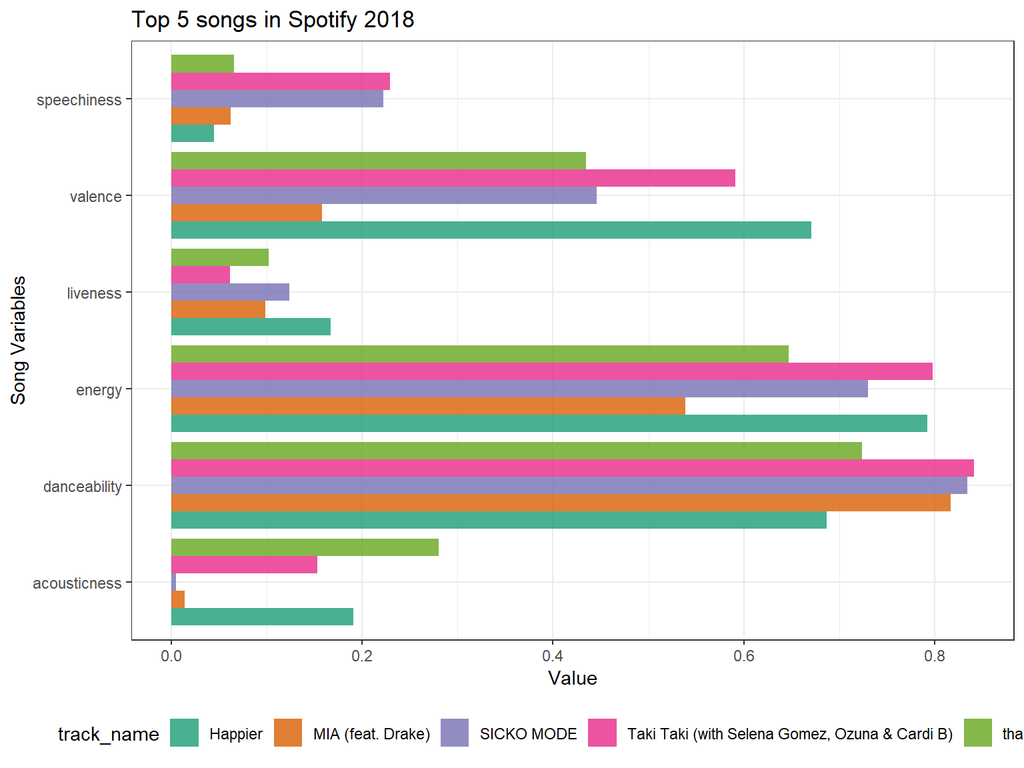

# Top 100 Songs by Key and Emotion

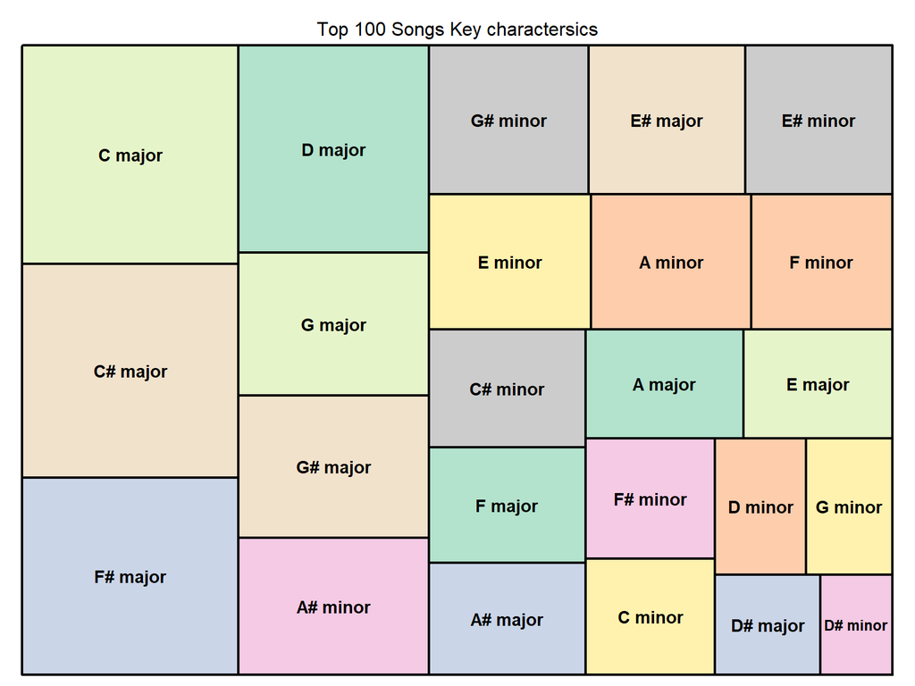

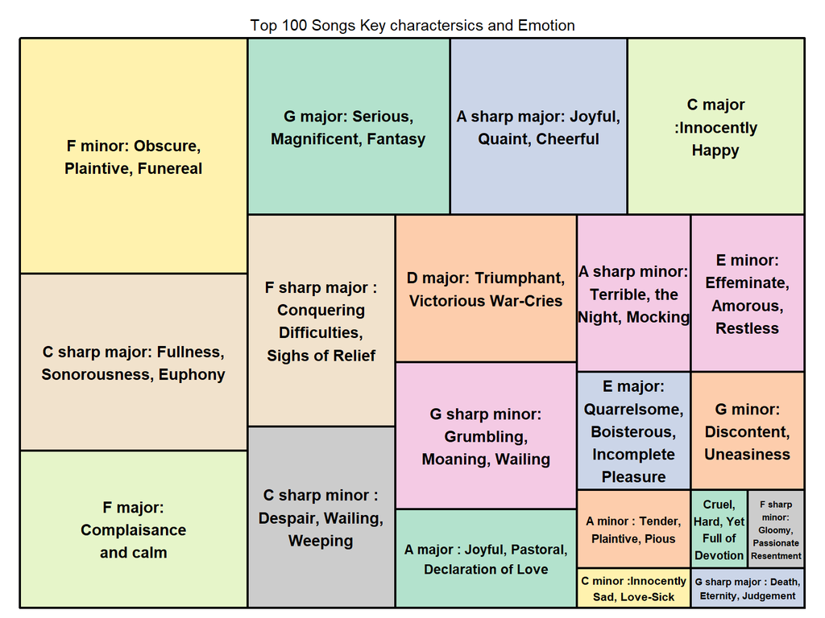

# Are danceable songs popular?

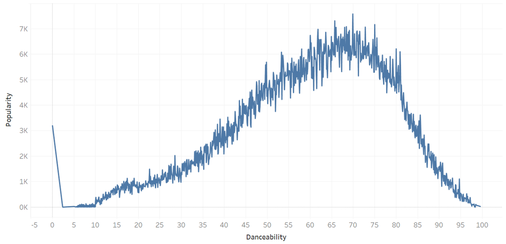

# How does mood affect the popularity of a song?

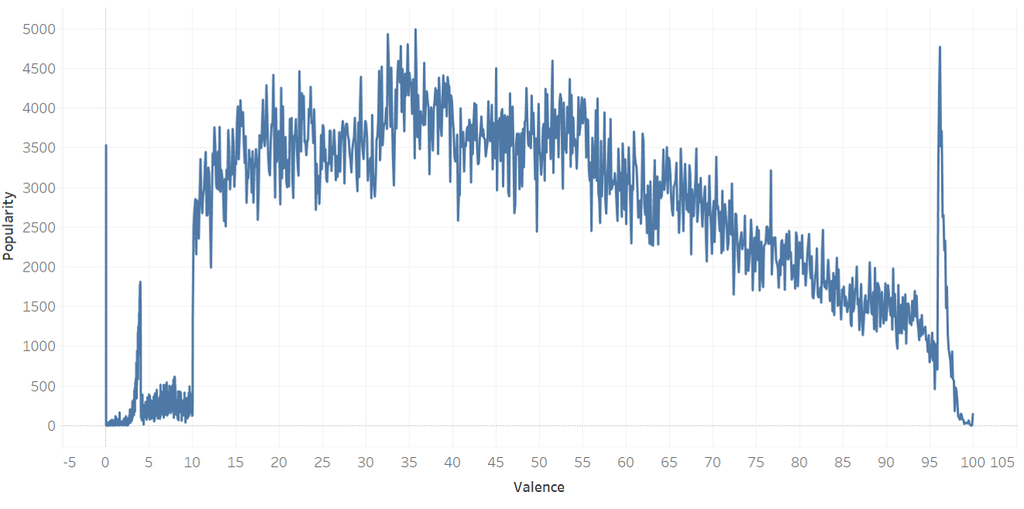

# Energy Vs. Popularity

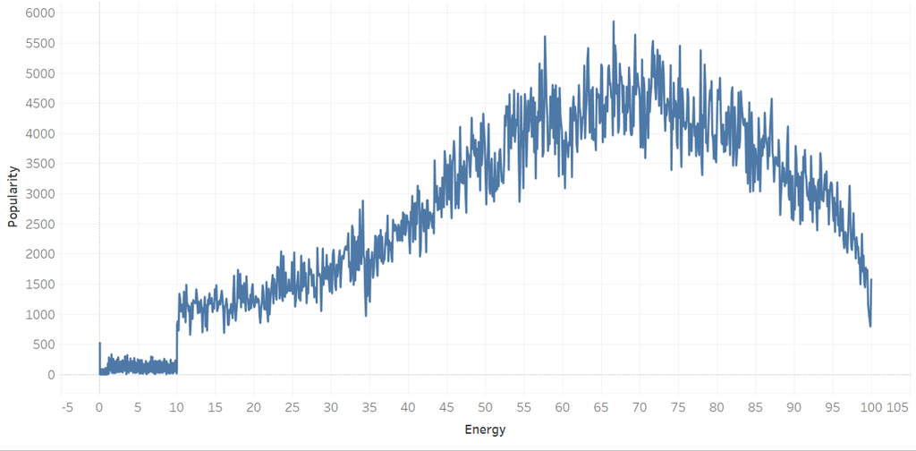

# Model Building and Evaluation

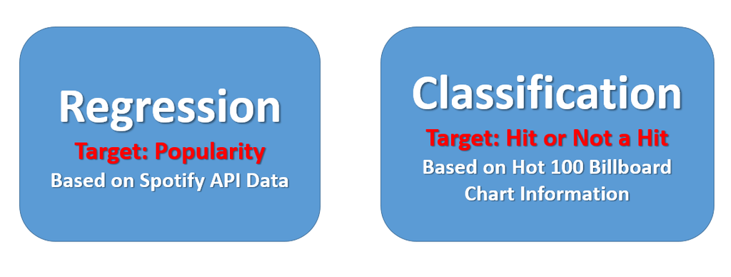

# The Regression Problem

Popularity is a copntinuous variable that ranges between 0 and 1

```
## [1] "Minimum Popularity is 0.1"
```

[output not shown]

Models considered:  
- Model appropriate for the random component of the response variable; a **GLM with beta random component**.  
- A model that relaxes assumptions of linearity and probability distribution; a nonparametric model **Multivariate Adaptive Regression Splines**

### The Beta Distribution

Ferrari and Cribari-Neto, 2004 proposed a reparametrization of the **Beta Distribution** , $\mu=p/(p+q)$ and $\phi=p+q$, with the density function being:
$$f(y \mid \mu,\phi)=\frac{\Gamma(\phi)}{\Gamma(\mu\phi)\Gamma((1-\mu)\phi)}y^{\mu\phi-1}(1-y)^{(1-\mu)\phi-1}, \;\;\; \;\;0<y<1$$

$$E(y)=\mu$$
and
$$Var(y)=\frac{\mu(1-\mu)}{1+\phi}$$
The parameter $\phi$ is known as the precision parameter. Notice that for fixed $\mu$, $\phi$ gets larger and variance of $y$ gets smaller. The inverse of $\phi^{-1}$ is also known as the dispersion parameter.

This parameterization is particularly useful in linear regression since it involves modeling the mean or the expected value of the response variable$(y)$. Thus $\mu$ is the mean of the response variable.

# The Beta [GLM] Model

Following the latter parameterization of the beta distribution proposed by Ferrari and Cribari-Neto(2004) above, let $y_1, y_2, ...,y_n$ be a random sample such that $y_i \sim Beta(\mu_i,\phi)\;\;\;\;i=1,2,...,n$. Then the beta regression model is defined as:

$$g(\mu_i)=x_i^T\beta$$
where $\beta=(\beta_1, \beta_2,...,\beta_p)$ is a $p\times1$ vector of unknown parameters$(p<n), \;\;x_i=(x_{i1},(x_{i},...,(x_{ip})^T$ is the vector of $p$ regressors or the independent variables of this model. $x_i^T\beta=\eta_i$ is the linear predictor or the systematic component of the model.

Also note that the link function represented by $g(*):(0,1) \implies \mathbb{R}$ is strictly increasing in $*$ and twice differentiable hence continuous everywhere.

Due the the link, random (beta distribution) and systematic component (linear predictor), the beta regression model can be modelled seen as a Generalized Linear Model (GLM) (Agresti et al. Categroical Data Analysis). This offers flexibility in the choice of the link function to suit particular cases. Some common link functions are:

### Some Common Link functions

- **logit** $g(\mu) = log(\frac{\mu}{1-\mu})$, thus $\mu=\frac{e^{x_i^T\beta}}{1+e^{x_i^T\beta}}$
- **log-log** $g(\mu) = log(-log(\mu))$
- **Probit** $g(\mu) = \phi^{-1}(\mu)$
- **Complimentary log-log** $g(\mu) = log(-log(1-\mu))$
- **Cauchit** $g(\mu) = tan(\pi (\mu - 0.5))$
- **Identity** $g(\mu) = \mu$

Like with most GLM, the inverse function $\mu=g^{-1}(x_i^T\beta)$, is a function (linear combination) of the regression parameters $\beta$, hence the maximum likelihood estimation is adopted.

# The Classification Problem

This problem is a classic case of class imbalance with the class of interest being roughly 10 percent of available data.

```
##
##         No        Yes
## 0.90100712 0.09899288
```

A rather simple criteria was adopted. Fit models that:

1. produces the best prediction of classes, and with a variable selection feature
2. produces the best prediction, and with the best variable explanation

Models that meet criteria 1: Models that employ Gradient Boosting Algorithms OR Bagging Algorithms. Due to serious computational constraints only the **XGBoost, C5.0** models were considered with optimal parameter turning.

Models that meet criteria 2: Models that employ Stacking or Bagging algorithms. Here, only the **logistic regression and random forest models** were considered.

# Model Building - Beta Regression Model

- First conduct feature selection using the Recursive Feature Elimination (RFE) algorithm
- Cross-validate model accross a combination of its tuning parameters using selected variables from the RFE: **the link function**, **parameter estimation criteria**, and the **precision parameter**

# The Beta Model